# Data Structure Basics

R Vocab Topics » Data Structures » Basics

- Data structure types
- Identify the structure
- Attributes

# Data Structure Types

The basic data structures in R can be organized by their dimensionality (1D, 2D, …, *n*D) and their “likeness” (homogenous vs. heterogeneous). This results in five data structure types most often used in data analysis; and almost all other objects in R are built from these foundational types:

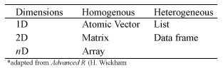

I have not had the need to use multi-dimensional arrays, therefore, the topics I will go into details on will include the vector, list, matrix, and data frame. These types represent the most commonly used data structures for day-to-day analyses.

# Identifying the Structure

Given an object, the best way to understand what data structure it is composed of is to use the structure function `str()`:

```r
# different data structures
vector <- 1:10
list <- list(item1 = 1:10, item2 = LETTERS[1:18])
matrix <- matrix(1:12, nrow = 4)
df <- data.frame(item1 = 1:18, item2 = LETTERS[1:18])

# identify the structure of each object
str(vector)
```

```
##  int [1:10] 1 2 3 4 5 6 7 8 9 10
```

```r
str(list)
```

```
## List of 2
##  $ item1: int [1:10] 1 2 3 4 5 6 7 8 9 10
##  $ item2: chr [1:18] "A" "B" "C" "D" ...
```

```r
str(matrix)
```

```
##  int [1:4, 1:3] 1 2 3 4 5 6 7 8 9 10 ...
```

```r
str(df)
```

```
## 'data.frame':    18 obs. of  2 variables:
##  $ item1: int  1 2 3 4 5 6 7 8 9 10 ...
##  $ item2: Factor w/ 18 levels "A","B","C","D",..: 1 2 3 4 5 6 7 8 9 10 ...
```

# Attributes

R objects can have attributes, which are like metadata for the object. These metadata can be very useful in that they help to describe the object. For example, column names on a data frame help to tell us what data are contained in each of the columns. Some examples of R object attributes are:

- names, dimnames
- dimensions (e.g. matrices, arrays)
- class (e.g. integer, numeric)
- length
- other user-defined attributes/metadata

Attributes of an object (if any) can be accessed using the `attributes()` function. Not all R objects contain attributes, in which case the `attributes()` function returns NULL.

```r
# assess attributes of an object
attributes(df)
```

```
## $names
## [1] "item1" "item2"
##
## $row.names
##  [1]  1  2  3  4  5  6  7  8  9 10 11 12 13 14 15 16 17 18
##
## $class
## [1] "data.frame"
```

```r
attributes(matrix)
```

```
## $dim
## [1] 4 3
```

```r
# assess names of an object
names(df)
```

```
## [1] "item1" "item2"
```

```r
# assess the dimensions of an object
dim(matrix)
```

```
## [1] 4 3
```

```r
# assess the class of an object
class(list)
```

```
## [1] "list"
```

```r
# access the length of an object
length(vector)
```

```
## [1] 10
```

```r
# note that length will measure the number of items in
# a list or number of columns in a data frame
length(list)
```

```
## [1] 2
```

```r
length(df)
```

```
## [1] 2
```

☛ *This section only shows you functions to assess these attributes. More details are provided on how to create attributes within each data structure type page.*

Go to top